# Modeling Smartphone Price Prediction Using Linear Regression

Annisa Indriani

2024-10-29

## Import Data

```r
library(readr)
data <- read.csv("Cellphone.csv", sep=";")
head(data)
```

```
##   Product_id Price Sale weight resoloution ppi cpu.core cpu.freq internal.mem
## 1        203  2357   10  135.0         5.2 424        8     1.35           16
## 2        880  1749   10  125.0         4.0 233        2     1.30            4
## 3         40  1916   10  110.0         4.7 312        4     1.20            8
## 4         99  1315   11  118.5         4.0 233        2     1.30            4
## 5        880  1749   11  125.0         4.0 233        2     1.30            4
## 6        947  2137   12  150.0         5.5 401        4     2.30           16
##     ram RearCam Front_Cam battery thickness
## 1 3.000   13.00         8    2610       7.4
## 2 1.000    3.15         0    1700       9.9
## 3 1.500   13.00         5    2000       7.6
## 4 0.512    3.15         0    1400      11.0
## 5 1.000    3.15         0    1700       9.9
## 6 2.000   16.00         8    2500       9.5
```

## Exploratory Data Analysis

### Check Data Structure

```r
str(data)
```

```
## 'data.frame':    161 obs. of  14 variables:
##  $ Product_id  : int  203 880 40 99 880 947 774 947 99 1103 ...
##  $ Price       : int  2357 1749 1916 1315 1749 2137 1238 2137 1315 2580 ...
##  $ Sale        : int  10 10 10 11 11 12 13 13 14 15 ...
##  $ weight      : num  135 125 110 118 125 ...
##  $ resoloution : num  5.2 4 4.7 4 4 5.5 4 5.5 4 5.1 ...
##  $ ppi         : int  424 233 312 233 233 401 233 401 233 432 ...
##  $ cpu.core    : int  8 2 4 2 2 4 2 4 2 4 ...
##  $ cpu.freq    : num  1.35 1.3 1.2 1.3 1.3 2.3 1.2 2.3 1.3 2.5 ...
##  $ internal.mem: num  16 4 8 4 4 16 8 16 4 16 ...
##  $ ram         : num  3 1 1.5 0.512 1 2 1 2 0.512 2 ...
##  $ RearCam     : num  13 3.15 13 3.15 3.15 16 2 16 3.15 16 ...
##  $ Front_Cam   : num  8 0 5 0 0 8 0 8 0 2 ...
##  $ battery     : int  2610 1700 2000 1400 1700 2500 1560 2500 1400 2800 ...
##  $ thickness   : num  7.4 9.9 7.6 11 9.9 9.5 11.7 9.5 11 8.1 ...
```

### Check Summary

```r
summary(data)
```

```
##    Product_id         Price           Sale            weight
##  Min.   :  10.0   Min.   : 614   Min.   :  10.0   Min.   : 66.0
##  1st Qu.: 237.0   1st Qu.:1734   1st Qu.:  37.0   1st Qu.:134.1
##  Median : 774.0   Median :2258   Median : 106.0   Median :153.0
##  Mean   : 675.6   Mean   :2216   Mean   : 621.5   Mean   :170.4
##  3rd Qu.:1026.0   3rd Qu.:2744   3rd Qu.: 382.0   3rd Qu.:170.0
##  Max.   :1339.0   Max.   :4361   Max.   :9807.0   Max.   :753.0
##   resoloution         ppi           cpu.core        cpu.freq
##  Min.   : 1.40   Min.   :121.0   Min.   :0.000   Min.   :0.000
##  1st Qu.: 4.80   1st Qu.:233.0   1st Qu.:4.000   1st Qu.:1.200
##  Median : 5.15   Median :294.0   Median :4.000   Median :1.400
##  Mean   : 5.21   Mean   :335.1   Mean   :4.857   Mean   :1.503
##  3rd Qu.: 5.50   3rd Qu.:428.0   3rd Qu.:8.000   3rd Qu.:1.875
##  Max.   :12.20   Max.   :806.0   Max.   :8.000   Max.   :2.700
##   internal.mem        ram           RearCam        Front_Cam
##  Min.   :  0.0   Min.   :0.000   Min.   : 0.00   Min.   : 0.000
##  1st Qu.:  8.0   1st Qu.:1.000   1st Qu.: 5.00   1st Qu.: 0.000
##  Median : 16.0   Median :2.000   Median :12.00   Median : 5.000
##  Mean   : 24.5   Mean   :2.205   Mean   :10.38   Mean   : 4.503
##  3rd Qu.: 32.0   3rd Qu.:3.000   3rd Qu.:16.00   3rd Qu.: 8.000
##  Max.   :128.0   Max.   :6.000   Max.   :23.00   Max.   :20.000
##     battery       thickness
##  Min.   : 800   Min.   : 5.100
##  1st Qu.:2040   1st Qu.: 7.600
##  Median :2800   Median : 8.400
##  Mean   :2842   Mean   : 8.922
##  3rd Qu.:3240   3rd Qu.: 9.800
##  Max.   :9500   Max.   :18.500
```

### Check Missing Values

```r
colSums(is.na(data))
```

```
##   Product_id        Price         Sale       weight  resoloution          ppi
##            0            0            0            0            0            0
##     cpu.core     cpu.freq internal.mem          ram      RearCam    Front_Cam
##            0            0            0            0            0            0
##      battery    thickness
##            0            0
```

### Correlation Heatmap

```r
library(dplyr)
```

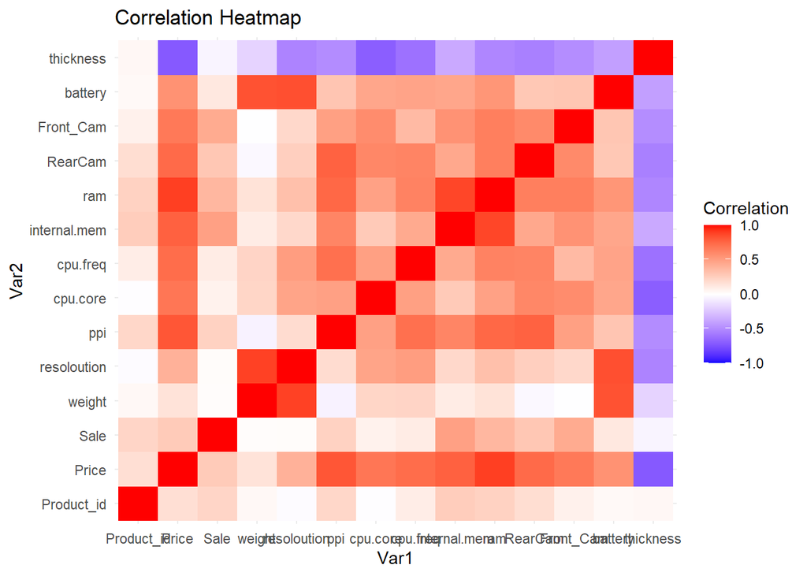

```r
correlation_matrix <- cor(data %>% select_if(is.numeric))

library(ggplot2)
library(reshape2)
melted_correlation <- melt(correlation_matrix)
ggplot(data = melted_correlation, aes(x = Var1, y = Var2, fill = value)) +
  geom_tile() +
  scale_fill_gradient2(low = 'blue', high = 'red', mid = 'white',
                       midpoint = 0, limit = c(-1, 1), name = 'Correlation') +
  theme_minimal() +
  labs(title = 'Correlation Heatmap')
```

## Linear Regression Model

### Price + Internal Memory

```r
library(lmtest)
m1 <- lm(Price ~ internal.mem, data = data)
summary(m1)
```

```
##
## Call:
## lm(formula = Price ~ internal.mem, data = data)
##
## Residuals:
##      Min       1Q   Median       3Q      Max
## -1148.52  -283.92    38.08   317.51   945.08
##
## Coefficients:
##              Estimate Std. Error t value Pr(>|t|)
## (Intercept)  1708.053     50.282   33.97   <2e-16 ***
## internal.mem   20.715      1.332   15.55   <2e-16 ***
## ---
## Signif. codes:  0 '***' 0.001 '**' 0.01 '*' 0.05 '.' 0.1 ' ' 1
##
## Residual standard error: 485.3 on 159 degrees of freedom
## Multiple R-squared:  0.6033, Adjusted R-squared:  0.6008
## F-statistic: 241.8 on 1 and 159 DF,  p-value: < 2.2e-16
```

From the summary above, we can see that the model is significant because the p-value is less than alpha 0.05. In addition, the variable also has a p-value below 0.05, which means that there is a relationship between internal memory and mobile phone price.

### Price + RAM

```r
m2 = lm(Price ~ ram, data = data)
summary(m2)
```

```
##
## Call:
## lm(formula = Price ~ ram, data = data)
##
## Residuals:
##     Min      1Q  Median      3Q     Max
## -784.84 -177.87  -19.85  243.00  760.15
##
## Coefficients:
##             Estimate Std. Error t value Pr(>|t|)
## (Intercept)  1271.87      45.64   27.87   <2e-16 ***
## ram           427.99      16.73   25.58   <2e-16 ***
## ---
## Signif. codes:  0 '***' 0.001 '**' 0.01 '*' 0.05 '.' 0.1 ' ' 1
##
## Residual standard error: 340.8 on 159 degrees of freedom
## Multiple R-squared:  0.8045, Adjusted R-squared:  0.8032
## F-statistic: 654.1 on 1 and 159 DF,  p-value: < 2.2e-16
```

From the summary above, we can see that the model is significant because the p-value is less than alpha 0.05. In addition, the variable also has a p-value below 0.05, which means that there is a relationship between RAM and mobile phone price.

### Price + Battery

```r
m3 = lm(Price ~ battery, data = data)
summary(m3)
```

```
##
## Call:
## lm(formula = Price ~ battery, data = data)
##
## Residuals:
##      Min       1Q   Median       3Q      Max
## -1819.60  -390.14    18.25   436.39  1382.92
##
## Coefficients:
##              Estimate Std. Error t value Pr(>|t|)
## (Intercept) 1.321e+03  1.164e+02  11.353  < 2e-16 ***
## battery     3.147e-01  3.692e-02   8.522 1.14e-14 ***
## ---
## Signif. codes:  0 '***' 0.001 '**' 0.01 '*' 0.05 '.' 0.1 ' ' 1
##
## Residual standard error: 638.5 on 159 degrees of freedom
## Multiple R-squared:  0.3135, Adjusted R-squared:  0.3092
## F-statistic: 72.62 on 1 and 159 DF,  p-value: 1.142e-14
```

From the summary above, we can see that the model is significant because the p-value is less than alpha 0.05. In addition, the variable also has a p-value below 0.05, which means that there is a relationship between battery and mobile phone price.

### Price + RearCam

```r
m4 = lm(Price ~ RearCam, data = data)
summary(m4)
```

```
##
## Call:
## lm(formula = Price ~ RearCam, data = data)
##
## Residuals:
##      Min       1Q   Median       3Q      Max
## -1137.76  -367.76   -18.54   268.97  1996.36
##
## Coefficients:
##             Estimate Std. Error t value Pr(>|t|)
## (Intercept) 1261.808     80.069   15.76   <2e-16 ***
## RearCam       91.903      6.634   13.85   <2e-16 ***
## ---
## Signif. codes:  0 '***' 0.001 '**' 0.01 '*' 0.05 '.' 0.1 ' ' 1
##
## Residual standard error: 518.7 on 159 degrees of freedom
## Multiple R-squared:  0.5469, Adjusted R-squared:  0.5441
## F-statistic: 191.9 on 1 and 159 DF,  p-value: < 2.2e-16
```

From the summary above, we can see that the model is significant because the p-value is less than alpha 0.05. In addition, the variable also has a p-value below 0.05, which means that there is a relationship between internal rear camera and mobile phone price.

### Price + Internal Memory + RAM + Battery + RearCam

```r
m5 = lm(Price ~ internal.mem + ram + battery + RearCam, data = data)
summary(m5)
```

```
##
## Call:
## lm(formula = Price ~ internal.mem + ram + battery + RearCam,
##     data = data)
##
## Residuals:
##     Min      1Q  Median      3Q     Max
## -692.78 -199.55  -28.44  223.35  590.33
##
## Coefficients:
##               Estimate Std. Error t value Pr(>|t|)
## (Intercept)  976.20067   59.96399  16.280  < 2e-16 ***
## internal.mem   3.34374    1.72491   1.939 0.054367 .
## ram          244.00212   38.12604   6.400 1.73e-09 ***
## battery        0.07615    0.01994   3.819 0.000193 ***
## RearCam       38.83330    5.12512   7.577 2.93e-12 ***
## ---
## Signif. codes:  0 '***' 0.001 '**' 0.01 '*' 0.05 '.' 0.1 ' ' 1
##
## Residual standard error: 288 on 156 degrees of freedom
## Multiple R-squared:  0.863,  Adjusted R-squared:  0.8595
## F-statistic: 245.6 on 4 and 156 DF,  p-value: < 2.2e-16
```

From the summary above, we can see that the model is significant as the p-value is smaller than alpha 0.05. In addition, all variables except internal memory have a p-value below 0.05, which means there is a relationship between ram, battery, rear cam and phone price.

### Price + RAM + Battery + RearCam

```r
m6 = lm(Price ~ ram + battery + RearCam, data = data)
summary(m6)
```

```
##
## Call:
## lm(formula = Price ~ ram + battery + RearCam, data = data)
##
## Residuals:
##     Min      1Q  Median      3Q     Max
## -547.83 -213.10  -11.06  206.13  622.32
##
## Coefficients:
##              Estimate Std. Error t value Pr(>|t|)
## (Intercept) 962.61348   60.07370  16.024  < 2e-16 ***
## ram         305.36888   21.43293  14.248  < 2e-16 ***
## battery       0.07368    0.02007   3.671 0.000331 ***
## RearCam      35.67473    4.90170   7.278 1.53e-11 ***
## ---
## Signif. codes:  0 '***' 0.001 '**' 0.01 '*' 0.05 '.' 0.1 ' ' 1
##
## Residual standard error: 290.5 on 157 degrees of freedom
## Multiple R-squared:  0.8597, Adjusted R-squared:  0.857
## F-statistic: 320.6 on 3 and 157 DF,  p-value: < 2.2e-16
```

From the summary above, we can see that the model is significant because the p-value is less than alpha 0.05. In addition, the variable also has a p-value below 0.05, which means there is a relationship between ram, battery, rear cam and phone price.

## Assumptions Test

### Independent

```r
dwtest(m1, alternative = "two.sided")
```

```
##
##  Durbin-Watson test
##
## data:  m1
## DW = 1.8303, p-value = 0.2667
## alternative hypothesis: true autocorrelation is not 0
```

```r
dwtest(m2, alternative = "two.sided")
```

```
##
##  Durbin-Watson test
##
## data:  m2
## DW = 1.7839, p-value = 0.1631
## alternative hypothesis: true autocorrelation is not 0
```

```r
dwtest(m3, alternative = "two.sided")
```

```
##
##  Durbin-Watson test
##
## data:  m3
## DW = 1.6714, p-value = 0.03457
## alternative hypothesis: true autocorrelation is not 0
```

```r
dwtest(m4, alternative = "two.sided")
```

```
##
##  Durbin-Watson test
##
## data:  m4
## DW = 1.586, p-value = 0.008175
## alternative hypothesis: true autocorrelation is not 0
```

```r
dwtest(m5, alternative = "two.sided")
```

```
##
##  Durbin-Watson test
##
## data:  m5
## DW = 1.7011, p-value = 0.05013
## alternative hypothesis: true autocorrelation is not 0
```

```r
dwtest(m6, alternative = "two.sided")
```

```
##
##  Durbin-Watson test
##
## data:  m6
## DW = 1.7436, p-value = 0.09394
## alternative hypothesis: true autocorrelation is not 0
```

The Durbin-Watson test results for Models 1, 2, 5, and 6 have a p-value of more than alpha 0.05, which indicates that the independence assumption is met. In contrast, for Models 3 and 4, the p-value is less than 0.05, indicating that the independence assumption is not met, and therefore, they cannot be used for further analysis.

### Identic

```r
library(car)
bptest(m1)
```

```
##
##  studentized Breusch-Pagan test
##
## data:  m1
## BP = 1.8869, df = 1, p-value = 0.1696
```

```r
bptest(m2)
```

```
##
##  studentized Breusch-Pagan test
##
## data:  m2
## BP = 0.056167, df = 1, p-value = 0.8127
```

```r
bptest(m5)
```

```
##
##  studentized Breusch-Pagan test
##
## data:  m5
## BP = 8.8432, df = 4, p-value = 0.06514
```

```r
bptest(m6)
```

```
##
##  studentized Breusch-Pagan test
##
## data:  m6
## BP = 2.7141, df = 3, p-value = 0.4378
```

The Breusch-Pagan test results for Models 1, 2, 5, and 6 have a p-value of more than alpha 0.05, indicating that the identical assumption is met.

### Normality

```r
library(nortest)
```

```r
e1 <- residuals(m1)
shapiro.test(e1)
```

```
##
##  Shapiro-Wilk normality test
##
## data:  e1
## W = 0.96872, p-value = 0.001043
```

```r
e2 <- residuals(m2)
shapiro.test(e2)
```

```
##
##  Shapiro-Wilk normality test
##
## data:  e2
## W = 0.98409, p-value = 0.06187
```

```r
e5 <- residuals(m5)
shapiro.test(e5)
```

```
##
##  Shapiro-Wilk normality test
##
## data:  e5
## W = 0.98425, p-value = 0.06464
```

```r
e6 <- residuals(m6)
shapiro.test(e6)
```

```
##
##  Shapiro-Wilk normality test
##
## data:  e6
## W = 0.97945, p-value = 0.01691
```

### Multicollinearity

```r
vif(m6)
```

```
##      ram  battery  RearCam
## 2.257327 1.427509 1.740863
```

A VIF value of less than 10 indicates that there is no multicollinearity in the RAM variable with other variables.

## Goodness of the Model

### MSE

```r
mean((e2^2))
```

```
## [1] 114675.7
```

### RMSE

```r
sqrt(mean((e2^2)))
```

```
## [1] 338.638
```

### AIC

```r
AIC(m2)
```

```
## [1] 2338.526
```

Although the value of evaluation metrics may not be as good or as small as other models, Model 2 is a model that can be used for analysis because there are no model assumptions that are violated.